# Exercise II - Correlation Only (25 Questions)

## CREATE LEVEL (3 vragen)

### Vraag Q24 (Create)

**Design a correlational study to investigate the relationship between social media usage and antisocial behavior in adolescents. What key design elements would you include?**

> **Hint:** Consider variables, measurement, sampling, controls, and ethical considerations.
1. Survey 100 teenagers about hours of social media use and self-reported antisocial acts  
   “1” = “❌ Incomplete. This design has several methodological weaknesses: (1) The sample size (N=100) is relatively small for detecting potentially subtle effects in behavioral research; (2) Simple self-reported hours fails to capture the complex, multidimensional nature of social media use (different platforms, active vs. passive use, content types, etc.); (3) No control variables means any observed correlation could be due to numerous confounding factors (socioeconomic status, parental supervision, personality traits, etc.); (4) Cross-sectional design prevents establishing temporal precedence, which is necessary for causal inference; (5) No validation measures for self-reported antisocial behavior increases measurement error. A robust correlational study requires addressing these methodological challenges.”
2. Longitudinal design measuring social media use (multiple platforms, time), antisocial behavior (multiple measures), controlling for age, SES, and family factors, with proper ethical oversight  
   “2” = “✅ Correct! This comprehensive design incorporates key methodological strengths: (1) Longitudinal measurement allows tracking changes over time and establishing temporal precedence (did social media use precede behavioral changes?); (2) Measuring multiple aspects of social media use (time spent, platform types, content engagement) captures the complexity of digital behavior; (3) Using multiple behavioral measures strengthens construct validity and reduces measurement error; (4) Controlling for important covariates like age, socioeconomic status, and family factors helps rule out alternative explanations; (5) Ethical oversight ensures participant protection, informed consent, data privacy, and appropriate risk management. This design maximizes the validity of potential correlational findings while minimizing methodological weaknesses.”
3. Experimental manipulation where some teens are assigned high social media use  
   “3” = “❌ Inappropriate. While experimental designs can establish causality more definitively than correlational designs, this approach has serious flaws: (1) Ethical concerns with potentially harmful manipulation—research ethics principles prohibit exposing participants, especially minors, to interventions that might increase risk for negative outcomes; (2) External validity problems, as artificially assigned social media use differs from natural, self-selected use patterns; (3) Ecological validity issues, since controlled experimental conditions poorly represent real-world social media engagement; (4) Retention challenges in maintaining compliance with assigned conditions over meaningful timeframes; (5) The question specifically asked for a correlational design, not an experimental one. Experimental designs have their place, but must be implemented ethically and appropriately.”
4. Simple correlation between total screen time and police contacts  
   “4” = “❌ Too simplistic. This approach has multiple conceptual and methodological weaknesses: (1) Total screen time is too general a measure, encompassing everything from homework to video games, not specifically social media use; (2) Police contacts represent only the most extreme and detected antisocial behaviors, missing the vast majority of minor and undetected behaviors; (3) Both measures are highly susceptible to selection biases, measurement error, and third-variable problems; (4) No consideration of important moderating factors (age, gender, socioeconomic context) that affect both variables; (5) Lacks measurement validity for both the independent and dependent variables. The resulting correlation would be difficult to interpret meaningfully due to these fundamental limitations.”

### Vraag Q25 (Create)

**Formulate a testable research hypothesis about the relationship between economic inequality and violent crime rates at the city level, including predicted direction and strength.**

> **Hint:** Create a specific, directional hypothesis that can be tested with correlation/regression.

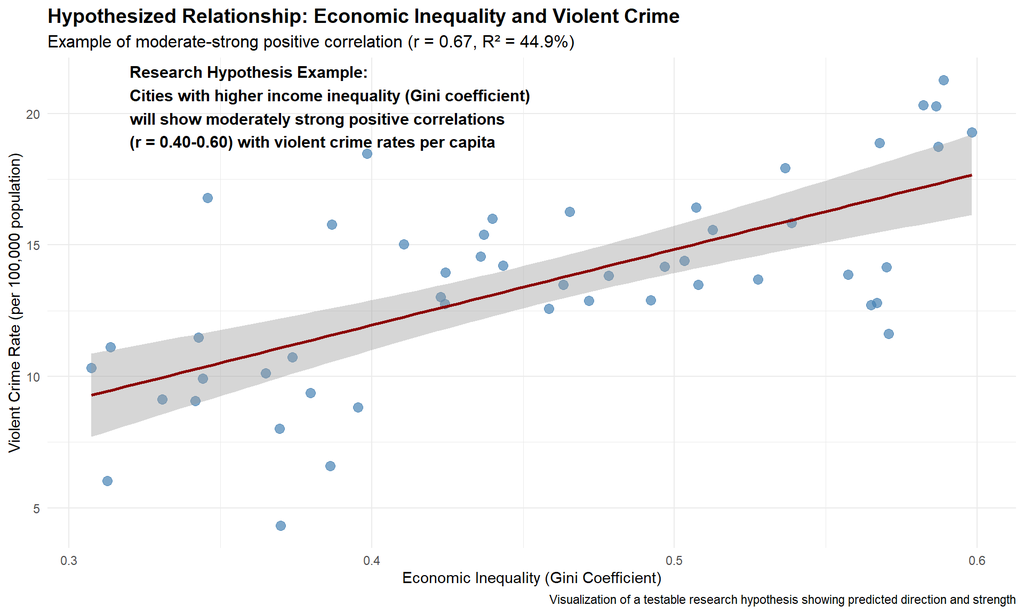

**Hypothesis Formulation Elements:** 1. **Variables:** Specifically defined and measurable (Gini coefficient, violent crime rate per 100,000) 2. **Direction:** Clear prediction (positive correlation) 3. **Magnitude:** Expected effect size range (r = 0.40-0.60) 4. **Unit of analysis:** Specified level (city-level) 5. **Testability:** Can be confirmed/rejected with statistical analysis

1. “Economic inequality affects crime somehow”  
   “1” = “❌ Too vague. This statement fails as a testable hypothesis for several reasons: (1) It lacks directionality—doesn’t specify whether inequality increases or decreases crime; (2) No operationalization of key variables—how is economic inequality measured? What type of crime?; (3) No unit of analysis—at what level (individual, neighborhood, city, country) is this relationship being examined?; (4) No predicted effect size or relationship strength; (5) No temporal scope is specified. A good research hypothesis needs precision in all these dimensions. Without such specificity, the claim remains a general statement that cannot be meaningfully tested with correlation or regression analysis, as it’s impossible to determine what would constitute evidence for or against it.”
2. “Cities with higher income inequality (Gini coefficient) will show moderately strong positive correlations (r = 0.40-0.60) with violent crime rates per capita”  
   “2” = “✅ Correct! This hypothesis exemplifies all key elements of a well-formulated, testable research prediction: (1) Clear specification of variables—income inequality measured by the Gini coefficient and violent crime rates per capita; (2) Explicit directionality—a positive correlation is predicted; (3) Defined magnitude—moderately strong correlation in the range of r = 0.40-0.60; (4) Appropriate unit of analysis—city-level comparison; (5) Implied research design—correlational analysis across multiple cities. This precise formulation allows for clear testing using statistical methods, with specific criteria for confirmation or rejection. The inclusion of an expected effect size range demonstrates sophisticated understanding of both the statistical methods and the substantive research area, allowing for meaningful interpretation of results regardless of the field of study.”
3. “Poor people commit more violent crimes”  
   “3” = “❌ Individual-level claim, inappropriate for several reasons: (1) This statement makes a causal claim about individual behavior rather than a correlation at the city level as requested; (2) It conflates economic status with inequality—poverty and inequality are related but distinct concepts; (3) It implies a direct causal relationship rather than a correlation; (4) The unit of analysis (individuals) doesn’t match what was requested (city-level); (5) No measurement operationalization is provided—how is poverty defined? How is crime measured? The fundamental mismatch between this individual-level causal claim and the requested city-level correlation hypothesis makes this answer incorrect, regardless of whether the underlying claim might be supported by other research approaches.”
4. “Economic inequality is the sole cause of all violent crime”  
   “4” = “❌ Too extreme and untestable. This statement fails as a hypothesis because: (1) It makes an absolute causal claim—identifying inequality as the ‘sole cause’—rather than proposing a correlation; (2) It uses universal language (‘all violent crime’) that would be invalidated by a single counterexample; (3) It lacks any specification of measurement for either variable; (4) It proposes a perfect relationship that contradicts the complexity of human behavior; (5) It cannot be meaningfully tested with correlation or regression analysis, as correlation coefficients, by nature, cannot establish sole causation. In any scientific field, hypotheses making absolute claims about sole causation are generally considered too extreme and fail to acknowledge the multivariate nature of complex phenomena.”